# Inferência estatística e regressão linear

Lista avaliativa 2 – Probabilidade e Estatística – 2022.2

fnaufel

(v. 29/11/2022)

# Instruções

- Clique o botão `Code`, no início desta página, para baixar o arquivo .Rmd deste documento.
- Certifique-se de que o pacote `fnaufelRmd` está instalado. Use os comandos

  ```r
  install.packages("devtools")
  devtools::install_github("fnaufel/fnaufelRmd")
  ```

- Edite o arquivo .Rmd para resolver a sua questão.
- Escreva o máximo possível sobre o seu raciocínio. Justifique suas respostas.
- Teste suas respostas. Tudo deve estar executando sem erros.
- Envie no Moodle o arquivo .Rmd com as suas resoluções.
- Bom trabalho.

# Ambiente

- Para gerar um arquivo HTML a partir deste documento, você precisa dos seguintes pacotes do R:
  - `conflicted`
  - `devtools`
  - `fnaufelRmd`
  - `kableExtra`
  - `knitr`
  - `latex2exp`
  - `sessioninfo`
  - `summarytools`
  - `tidyverse`
- Execute o seguinte código para instalar os pacotes que estão faltando no seu ambiente:

  ```r
  if (!require('devtools'))
    install.packages('devtools')

  if (!require('fnaufelRmd'))
    devtools::install_github("fnaufel/fnaufelRmd")

  pacotes <- c(
    'conflicted',
    'kableExtra',
    'knitr',
    'latex2exp',
    'sessioninfo',
    'summarytools',
    'tidyverse'
  )

  instalar_se_preciso <- function(x) {

    if (!require(x, character.only = TRUE))
      install.packages(x)

  }

  invisible(sapply(pacotes, instalar_se_preciso))
  ```

- Se houver erro na instalação, entre em contato com o professor pelo Telegram, enviando todas as mensagens emitidas quando você executou os comandos.

# 1 Moeda

Eu tenho uma moeda, que pode ou não ser justa.

Eu empresto esta moeda para cada um de vocês.

Cada um de vocês lança a moeda $200$ vezes e anota o número de caras obtidas.

Os resultados estão na tabela:

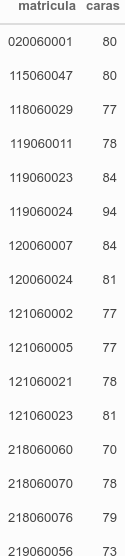

Cada item que pede para você construir um intervalo de confiança ou para você fazer um teste de hipóteses deve ser resolvido de duas maneiras:

1. Fazendo os cálculos passo a passo, como nos vídeos do curso, e
2. Usando as funções prontas do R para IC e testes de hipótese que foram usadas nos vídeos do curso.
1. Usando apenas a linha da tabela que corresponde a você, teste a hipótese de que a moeda é justa — i.e., em um lançamento, a moeda produz cara com probabilidade $p = 0{,}5$. Use $\alpha = 0{,}05$.
2. Usando apenas a linha da tabela que corresponde a você, construa um intervalo de confiança com nível de confiança de $95\%$ para a verdadeira probabilidade de a moeda produzir cara em um lançamento.
3. A tabela acima foi gerada por mim através de uma simulação. Eu sei a verdadeira probabilidade de a moeda produzir cara em um lançamento. Se todos os alunos responderem a esta questão, quantos dos intervalos de confiança não vão conter a probabilidade verdadeira de a moeda produzir cara?

# 2 Lei de Moore para GPUs

A [lei de Moore](https://pt.wikipedia.org/wiki/Lei_de_Moore) estima que, a cada dois anos, o número de transistores em um circuito integrado dobra.

Siga os passos no final do vídeo em https://youtu.be/diUFBf0JUC4 (arquivo .Rmd em https://github.com/fnaufel/CursoProbEst/blob/master/Aulas/23-regressao1/regressao1.Rmd) para examinar a lei de Moore para GPUs:

Use o *dataset* abaixo:

```r
gpus <-
  read_csv2(
    paste0(
      'https://raw.githubusercontent.com/fnaufel/',
      'CursoProbEst/master/Aulas/23-regressao1/data/gpus.csv'
    )
  ) %>%
  select(
    processador = Processor,
    transistores = 'Transistor count',
    ano = 'Date of introduction',
    fabricante = Manufacturer
  )

gpus
```

| processador | transistores | ano | fabricante |
| --- | --- | --- | --- |
| NV3 | 3500000 | 1997 | NVIDIA |
| Rage 128 | 8000000 | 1999 | AMD |
| NV5 | 15000000 | 1999 | Nvidia |
| NV10 | 23000000 | 1999 | Nvidia |
| NV11 | 20000000 | 2000 | Nvidia |
| NV15 | 25000000 | 2000 | Nvidia |
| R100 | 30000000 | 2000 | AMD |
| NV20 | 57000000 | 2001 | Nvidia |
| R200 | 60000000 | 2001 | AMD |
| NV25 | 63000000 | 2002 | Nvidia |

[output cut: 25 more lines]